# Assignment 2: Exploratory Analysis of Measured Features to Separate Benign and Malignant Cells

Group 11: Anjali Menon, Rhea Kaul, Hayden Scott

10/16/2021

```r
library(devtools)
```

```r
library(ggbiplot)
library(dplyr)
```

**In order to make the dimensions usable we must perform dimensionality reduction of the data using the following steps**

```r
ovarian.dataset <- read.delim("C:/Users/Owner/Downloads/BMEG310_2021-main (1)/BMEG310_2021-main/Assignment 2/ovarian.data", sep=",", header = FALSE)
features <- c("perimeter", "area", "smoothness", "symmetry", "concavity", paste("protein ", seq(1, 25) ))
names(ovarian.dataset) <- c("cell_id", "diagnosis", features) # paste0(features,"_mean"), paste0(features,"_se"), paste0(features,"_worst"))
```

# Question 1 DIMENSIONALITY REDUCTION

## Q1.1. Performing PCA on the features of the dataset and reporting variation

```r
ovarian.pca <- prcomp(ovarian.dataset[,c(3:32)],center = TRUE,scale. = TRUE)
summary(ovarian.pca)
```

```
## Importance of components:
##                           PC1    PC2     PC3     PC4     PC5    PC6    PC7
## Standard deviation     3.5820 2.2873 1.62395 1.37410 1.24910 1.0844 0.8306
## Proportion of Variance 0.4277 0.1744 0.08791 0.06294 0.05201 0.0392 0.0230
## Cumulative Proportion  0.4277 0.6021 0.68997 0.75291 0.80492 0.8441 0.8671
##                            PC8     PC9    PC10    PC11   PC12   PC13   PC14
## Standard deviation     0.74686 0.67762 0.61684 0.60200 0.5771 0.5139 0.5021
## Proportion of Variance 0.01859 0.01531 0.01268 0.01208 0.0111 0.0088 0.0084
## Cumulative Proportion  0.88571 0.90101 0.91369 0.92578 0.9369 0.9457 0.9541
##                           PC15   PC16   PC17    PC18    PC19    PC20   PC21
## Standard deviation     0.45896 0.3989 0.3834 0.36254 0.32797 0.30949 0.3001
## Proportion of Variance 0.00702 0.0053 0.0049 0.00438 0.00359 0.00319 0.0030
## Cumulative Proportion  0.96110 0.9664 0.9713 0.97569 0.97928 0.98247 0.9855
##                           PC22    PC23    PC24   PC25    PC26    PC27    PC28
## Standard deviation     0.27191 0.26081 0.24722 0.2326 0.22154 0.20068 0.18042
## Proportion of Variance 0.00246 0.00227 0.00204 0.0018 0.00164 0.00134 0.00108
## Cumulative Proportion  0.98794 0.99020 0.99224 0.9940 0.99568 0.99702 0.99811
##                           PC29    PC30
## Standard deviation     0.17164 0.16532
## Proportion of Variance 0.00098 0.00091
## Cumulative Proportion  0.99909 1.00000
```

## Q1.2.Dimensionality of the reduced feature space to preserve 90% variability

**In order to represent 90% of the variance in the data by dimensionality reduction, the number of PCs required is at least 9. This is because the cumulative proportion PC9 is approximately 90% and PC10 is 91%.**

## Q1.3.Plotting observations using 2 different colours

### GRAPH 1: Plot of PC1 AND PC2

```r
str(ovarian.pca)
```

```
## List of 5
##  $ sdev    : num [1:30] 3.58 2.29 1.62 1.37 1.25 ...
##  $ rotation: num [1:30, 1:30] -0.22 -0.11 -0.229 -0.222 -0.137 ...
##   ..- attr(*, "dimnames")=List of 2
##   .. ..$ : chr [1:30] "perimeter" "area" "smoothness" "symmetry" ...
##   .. ..$ : chr [1:30] "PC1" "PC2" "PC3" "PC4" ...
##  $ center  : Named num [1:30] 14.1809 19.3922 92.1982 663.7854 0.0965 ...
##   ..- attr(*, "names")= chr [1:30] "perimeter" "area" "smoothness" "symmetry" ...
##  $ scale   : Named num [1:30] 3.5715 4.2746 24.1993 354.8356 0.0142 ...
##   ..- attr(*, "names")= chr [1:30] "perimeter" "area" "smoothness" "symmetry" ...
##  $ x       : num [1:625, 1:30] -4.476 0.448 1.916 1.874 -2.802 ...
##   ..- attr(*, "dimnames")=List of 2
##   .. ..$ : NULL
##   .. ..$ : chr [1:30] "PC1" "PC2" "PC3" "PC4" ...
##  - attr(*, "class")= chr "prcomp"
```

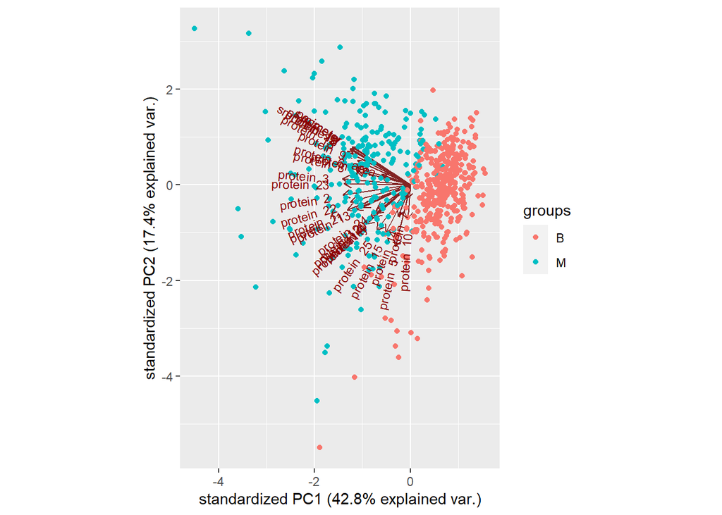

```r
ovarian.dataset.v2 <- ovarian.dataset[,2]
ggbiplot(ovarian.pca,choices=c(1,2),groups=ovarian.dataset.v2)
```

## Q1.4.Plotting Area and Concaivity features associated with cells

### GRAPH 2: Plot of Area and Concaivity

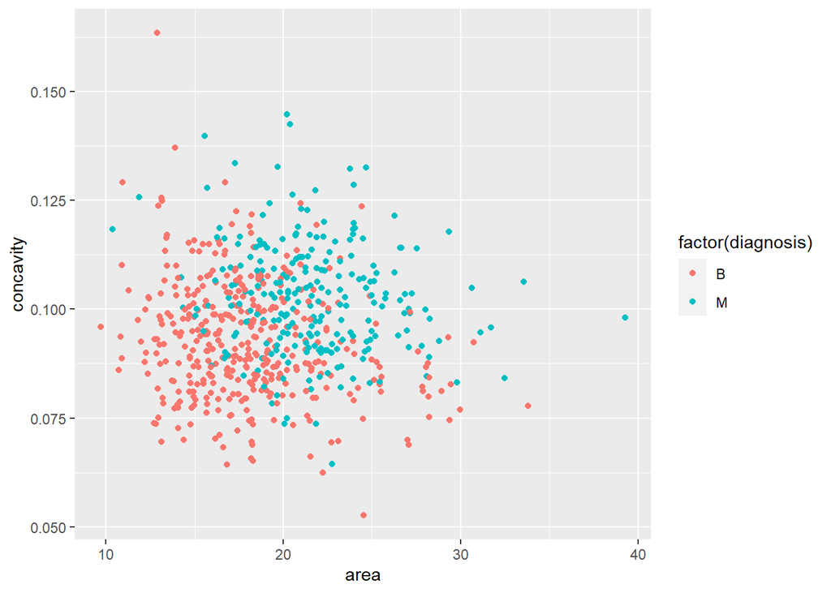

```r
ggplot(ovarian.dataset, aes(x=area,y=concavity,color= factor(diagnosis)))+geom_point()
```

## Q1.5.Difference between the two plots:

**The PCA gives a more reduced and accurate plot of the values compared to the unreduced one, which shows no separation. However, due to the reduced variance in the data, the clusters overlap and give us an unclear separation. Reducing the dimensionality by comparing just area and concavity does give a less crowded graph but due to the reduced variance in the data, the clusters overlap and give us an unclear separation**

## Q1.6.Plotting Distributions of the PCs

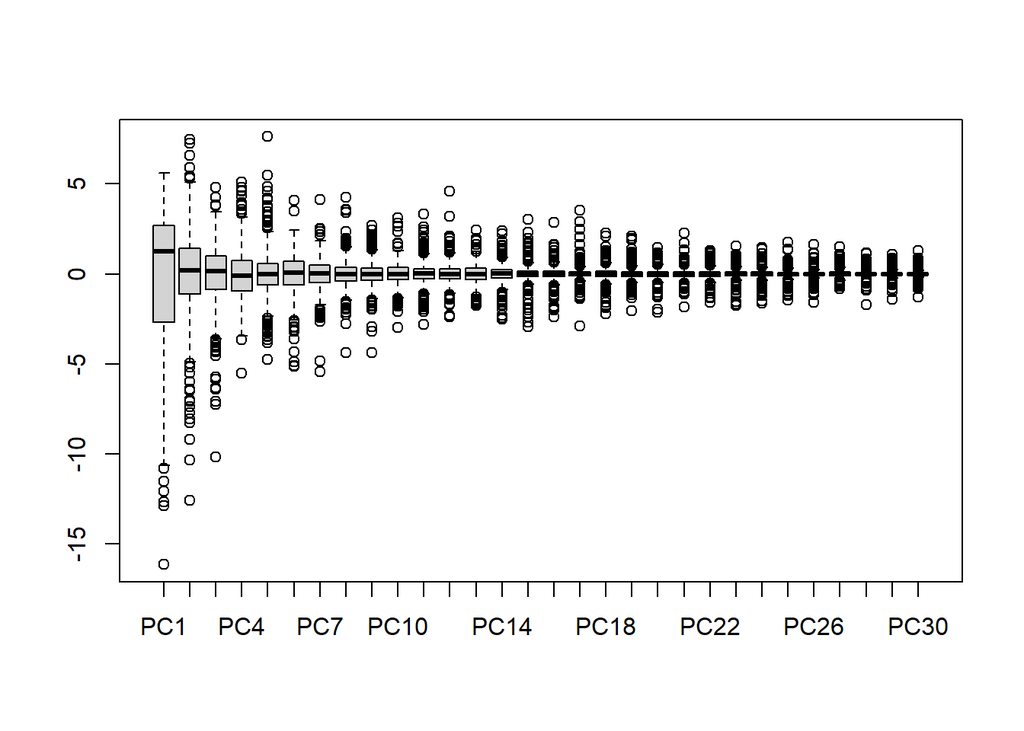

```r
boxplot(ovarian.pca$x)
```

# Question 2 CLUSTERING

## Q2.1. Applying Kmeans clustering on data

```r
set.seed(786)
input <-as.data.frame(scale(ovarian.dataset[,c(3:32)]))
clustering <- kmeans(input,2)
labels <- ifelse(clustering$cluster== 1, "M", "B")
diagnosiscountM <- sum(labels=="M")
diagnosiscountM
```

```
## [1] 219
```

```r
diagnosiscountB<-625-diagnosiscountM
diagnosiscountB
```

```
## [1] 406
```

```r
c.mat<-table(labels, ovarian.dataset$diagnosis)
c.mat
```

```
##
## labels   B   M
##      B 371  35
##      M  14 205
```

```r
acc = (c.mat[1,1] + c.mat[2,2])/length(labels)
recall = c.mat[1,1]/(c.mat[1,1]+c.mat[2,1])
precision = c.mat[1,1]/(c.mat[1,1]+c.mat[1,2])


clusternumM<- sum(ovarian.dataset$diagnosis =="M")
clusternumB<- 625-clusternumM
clusternumM
```

```
## [1] 240
```

```r
clusternumB
```

```
## [1] 385
```

```r
acc
```

```
## [1] 0.9216
```

```r
recall
```

```
## [1] 0.9636364
```

```r
precision
```

```
## [1] 0.9137931
```

**Please note that the values change each time and the following values are given for a single instance of the data!**

**2 Named clusters are: B = 385 and M = 240 concordance between clusters: Cluster count B = 406 and M = 219**

**The cluster count is close to the actual count is off by about 21. The accuracy is 0.92 while the precision and recall are 0.91 and 0.96 respectively, which means that the concordance is high.**

## Q2.2.Kmeans analysis 10 times and reporting mean accuracy

```r
(accuracy <- c(1:10))
```

```
##  [1]  1  2  3  4  5  6  7  8  9 10
```

```r
for(i in 1:10)
{
  ovarian.val <- select(ovarian.dataset, -2)
  ovarian.normalization <- as.data.frame(scale(ovarian.val))
  clustering <- kmeans(ovarian.normalization,2,nstar = 1)
  labels <- ifelse(clustering$cluster== 1, "M", "B")
  c.mat<-table(labels, ovarian.dataset$diagnosis)
  accuracy[i] =(c.mat[1,1] + c.mat[2,2])/length(labels)

}
accuracy
```

```
##  [1] 0.9216 0.0784 0.0784 0.0784 0.9216 0.0784 0.9216 0.0784 0.9216 0.0784
```

```r
mean(accuracy)
```

```
## [1] 0.41568
```

**In each run the results are different because the variance changes each time. Picking different starting points for the analysis randomly is what causes the results to vary each time.**

## Q2.3. Repeating Analysis with top 5 PC’s

```r
(accuracy.pca <- c(1:10))
```

```
##  [1]  1  2  3  4  5  6  7  8  9 10
```

```r
for(i in 1:10)
{
  ovarian.dataframe <- as.data.frame(predict(ovarian.pca, ovarian.dataset))
  ovarian.dataframe <- subset(ovarian.dataframe, select = c(1:5))

  clustering.pca <- kmeans(ovarian.dataframe,2,nstar = 2)
  labels <- ifelse(clustering.pca$cluster== 1, "M", "B")
  c.mat<-table(labels, ovarian.dataset$diagnosis)

  accuracy.pca[i] = (c.mat[1,1] + c.mat[2,2])/length(labels)

}
accuracy.pca
```

```
##  [1] 0.9184 0.0816 0.0816 0.9184 0.0784 0.0784 0.9216 0.9184 0.0816 0.9184
```

```r
mean(accuracy.pca)
```

```
## [1] 0.49968
```

# Q3 CLASSIFICATION

## Dividing data into training and test sets

```r
ovarian.dataset.train <- ovarian.dataset[sample(nrow(ovarian.dataset))[1:(nrow(ovarian.dataset)/2)],]
ovarian.dataset.test <- ovarian.dataset[sample(nrow(ovarian.dataset))[(nrow(ovarian.dataset)/2):(nrow(ovarian.dataset))],]
```

## Q3.1.

```r
ovarian.fit <- glm(as.factor(diagnosis) ~ .- cell_id , data = ovarian.dataset.train, family = binomial)
summary(ovarian.fit)
```

```
##
## Call:
## glm(formula = as.factor(diagnosis) ~ . - cell_id, family = binomial,
##     data = ovarian.dataset.train)
##
## Deviance Residuals:
##        Min          1Q      Median          3Q         Max
## -1.157e-04  -2.100e-08  -2.100e-08   2.100e-08   1.030e-04
##
## Coefficients:
##                 Estimate Std. Error z value Pr(>|z|)
## (Intercept)   -1.220e+03  4.480e+05  -0.003    0.998
## perimeter      2.064e+01  3.597e+04   0.001    1.000
## area           1.427e+01  6.704e+03   0.002    0.998
## smoothness     7.533e-01  3.336e+03   0.000    1.000
## symmetry      -4.028e-01  1.827e+02  -0.002    0.998
## concavity      5.078e+02  1.813e+06   0.000    1.000
## `protein  1`  -8.183e+01  9.336e+05   0.000    1.000
## `protein  2`   7.610e+02  8.908e+05   0.001    0.999
## `protein  3`  -7.249e+01  1.632e+06   0.000    1.000
## `protein  4`   7.120e+01  7.041e+05   0.000    1.000
## `protein  5`   1.130e+03  4.183e+06   0.000    1.000
## `protein  6`   3.234e+02  2.046e+05   0.002    0.999
## `protein  7`   7.799e+01  4.379e+04   0.002    0.999
## `protein  8`  -4.355e+01  6.670e+04  -0.001    0.999
## `protein  9`   1.374e+00  2.545e+03   0.001    1.000
## `protein  10` -5.405e+02  1.144e+07   0.000    1.000
## `protein  11` -1.065e+03  3.060e+06   0.000    1.000
## `protein  12` -3.666e+02  9.772e+05   0.000    1.000
## `protein  13`  8.323e+03  5.998e+06   0.001    0.999
## `protein  14` -4.005e+03  3.301e+06  -0.001    0.999
## `protein  15` -2.786e+04  2.654e+07  -0.001    0.999
## `protein  16`  8.595e+00  2.423e+04   0.000    1.000
## `protein  17` -7.854e+00  5.278e+03  -0.001    0.999
## `protein  18`  4.197e+00  5.549e+03   0.001    0.999
## `protein  19` -4.572e-02  1.561e+02   0.000    1.000
## `protein  20` -9.722e+02  1.802e+06  -0.001    1.000
## `protein  21` -2.062e+02  4.927e+05   0.000    1.000
## `protein  22`  7.764e+01  2.145e+05   0.000    1.000
## `protein  23` -5.877e-01  7.714e+05   0.000    1.000
## `protein  24`  4.195e+02  4.750e+05   0.001    0.999
## `protein  25`  3.838e+03  2.009e+06   0.002    0.998
##
## (Dispersion parameter for binomial family taken to be 1)
##
##     Null deviance: 4.1846e+02  on 311  degrees of freedom
## Residual deviance: 7.6154e-08  on 281  degrees of freedom
## AIC: 62
##
## Number of Fisher Scoring iterations: 25
```

```r
ovarian.probability_1 <- predict(ovarian.fit, newdata = ovarian.dataset.train, type = "response")
ovarian.prediction_1 <- ifelse(ovarian.probability_1 > 0.5,"M", "B")
summary(ovarian.prediction_1)
```

```
##    Length     Class      Mode
##       312 character character
```

```r
cm.trainingset <- table(ovarian.prediction_1,ovarian.dataset.train$diagnosis)
cm.trainingset
```

```
##
## ovarian.prediction_1   B   M
##                    B 189   0
##                    M   0 123
```

```r
accuracy_1 = (cm.trainingset[1,1] + cm.trainingset[2,2])/length(ovarian.prediction_1)
precision_1 = cm.trainingset[1,1]/(cm.trainingset[1,1]+cm.trainingset[2,1])
recall_1 = cm.trainingset[1,1]/(cm.trainingset[1,1]+cm.trainingset[1,2])

accuracy_1
```

```
## [1] 1
```

```r
precision_1
```

```
## [1] 1
```

```r
recall_1
```

```
## [1] 1
```

```r
ovarian.probability_2<-predict(ovarian.fit,newdata = ovarian.dataset.test,type = "response")
ovarian.prediction_2 <- ifelse(ovarian.probability_2 > 0.5,"M","B")
summary(ovarian.prediction_2)
```

```
##    Length     Class      Mode
##       313 character character
```

```r
cm.test <- table(ovarian.prediction_2,ovarian.dataset.test$diagnosis)
cm.test
```

```
##
## ovarian.prediction_2   B   M
##                    B 201   3
##                    M   3 106
```

```r
accuracy_2 = (cm.test[1,1] + cm.test[2,2])/length(ovarian.prediction_2)
precision_2 = cm.test[1,1]/(cm.test[1,1]+cm.test[2,1])
recall_2 = cm.test[1,1]/(cm.test[1,1]+cm.test[1,2])

accuracy_2
```

```
## [1] 0.9808307
```

```r
precision_2
```

```
## [1] 0.9852941
```

```r
recall_2
```

```
## [1] 0.9852941
```

**Training Set Data:** **Accuracy = 1 Precision = 1 Recall = 1**

**Through these results it can be seen that the classifier performs better on the training set vs the test set. Specifically speaking, since all values are 1, this means that ever result that was retrieved through a search algorithm was relevant.The classifier performed better on the training set since the model was trained on the training data itself. This means that the model has seen the data already and is more likey to search for all of the relavent values. This is different than the test data since the computer has not seen the data, it is harder for it to reproduce relavent search results**

## Q3.2.

```r
ovarian.dataset.pca <- prcomp(ovarian.dataset[,c(3:32)],center = TRUE,scale. = TRUE)
ovarian.training.pca = as.data.frame(predict(ovarian.dataset.pca, ovarian.dataset.train))
ovarian.testing.pca = as.data.frame(predict(ovarian.dataset.pca, ovarian.dataset.test))


ovarian.training.pca = subset(ovarian.training.pca, select = c(1:5))
ovarian.training.kmean <- kmeans(ovarian.training.pca, 2, nstar = 1)

ovarian.training.pca$diagnosis = ovarian.dataset.train$diagnosis
predict_ovarian_labels <- ifelse(ovarian.training.kmean$cluster == 1, "M", "B")


cm.trainingset <- table(predict_ovarian_labels,ovarian.training.pca$diagnosis)
cm.trainingset
```

```
##
## predict_ovarian_labels   B   M
##                      B   4 107
##                      M 185  16
```

```r
accuracy_pca_1 <- (cm.trainingset[1,1] + cm.trainingset[2,2])/length(predict_ovarian_labels)
precision_pca_1 <- cm.trainingset[1,1]/(cm.trainingset[1,1]+cm.trainingset[2,1])
recall_pca_1 <- cm.trainingset[1,1]/(cm.trainingset[1,1]+cm.trainingset[1,2])

accuracy_pca_1
```

```
## [1] 0.06410256
```

```r
precision_pca_1
```

```
## [1] 0.02116402
```

```r
recall_pca_1
```

```
## [1] 0.03603604
```

```r
ovarian.testing.pca = subset(ovarian.testing.pca, select = c(1:5))
ovarian.testing.kmean <- kmeans(ovarian.testing.pca, 2, nstar = 1)

ovarian.testing.pca$diagnosis = ovarian.dataset.test$diagnosis
predict_ovarian_labels_test <- ifelse(ovarian.testing.kmean$cluster == 1, "M", "B")

cm.testingset <- table(predict_ovarian_labels_test,ovarian.testing.pca$diagnosis)
cm.testingset
```

```
##
## predict_ovarian_labels_test   B   M
##                           B 195  15
##                           M   9  94
```

```r
accuracy_pca_2 <- (cm.testingset[1,1] + cm.testingset[2,2])/length(predict_ovarian_labels_test)
precision_pca_2 <- cm.testingset[1,1]/(cm.testingset[1,1]+cm.testingset[2,1])
recall_pca_2 <- cm.testingset[1,1]/(cm.testingset[1,1]+cm.testingset[1,2])

accuracy_pca_2
```

```
## [1] 0.9233227
```

```r
precision_pca_2
```

```
## [1] 0.9558824
```

```r
recall_pca_2
```

```
## [1] 0.9285714
```

## Q3.3.

**The values in 3.2 are lower than that of 3.1 for one instance of the data set. Please note that due to the kmeans clustering feature, each time the data set is divided into training and test data, the value changes due to the difference in selected centroid value. However we believe that this makes sense since the these values keep changing as the threshold is increased or decreased. Furthermore, PCA values are lesser since the dimensions are reduced. Due to this reduced dimension the data is less categorical, and classification will not produce results as accurately or precisely**

## Q3.4.

**Classification is a supervised learning algorithm and uses labelled data as the input. Clustering is an unsupervised learning algorithm and uses unlabeled data as the input. In our data, Classification has better results than clustering. This is most likely because classification is better suited to sorting labeled categorical data, which our diagnosis data most closely resembles. If we were trying to sort the data by some non-categorical data, clustering would perform better.**

## Q3.5.

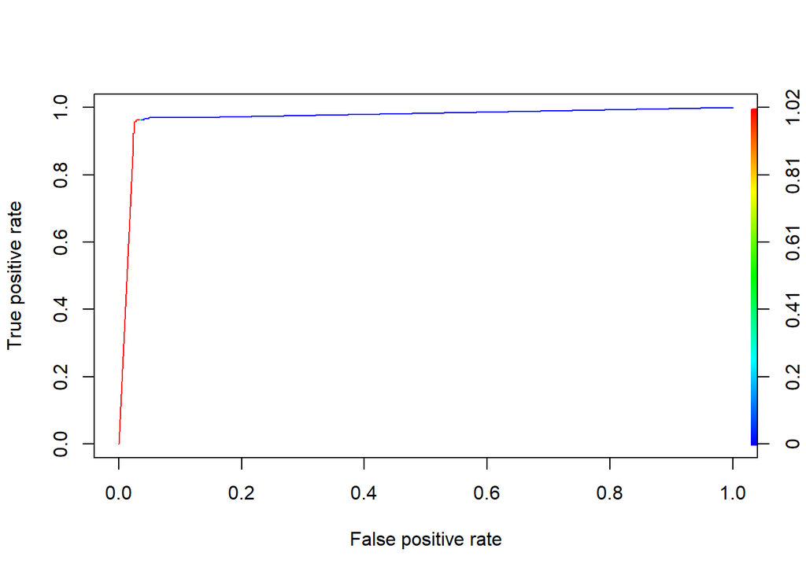

```r
library(ROCR)
probability.predictor <- predict(ovarian.fit, ovarian.dataset, type="response")
prediction <- prediction(probability.predictor, ovarian.dataset$diagnosis, label.ordering=c("B","M"))
perform.plot <- performance(prediction,"tpr","fpr")
plot(perform.plot,colorize=TRUE)
```

## Q3.6.

**Performing random forest classification for training and testing data**

```r
library(randomForest)
set.seed(69)

dataset.6.train <- ovarian.dataset[sample(nrow(ovarian.dataset))[1:(nrow(ovarian.dataset)/2)],]
dataset.6.test <- ovarian.dataset[sample(nrow(ovarian.dataset))[(nrow(ovarian.dataset)/2):(nrow(ovarian.dataset))],]

names(dataset.6.train) <- make.names(names(dataset.6.train))
names(dataset.6.test) <- make.names(names(dataset.6.test))

model.6 <- randomForest(as.factor(diagnosis) ~ . - cell_id,dataset.6.train)
summary(model.6$y)
```

```
##   B   M
## 190 122
```

```r
cm.treetrain <- table(model.6$y,dataset.6.train$diagnosis)
cm.treetrain
```

```
##
##       B   M
##   B 190   0
##   M   0 122
```

```r
accuracy_tra = (cm.treetrain[1,1] + cm.treetrain[2,2])/length(model.6$y)
precision_tra = cm.treetrain[1,1]/(cm.treetrain[1,1]+cm.treetrain[2,1])
recall_tra = cm.treetrain[1,1]/(cm.treetrain[1,1]+cm.treetrain[1,2])

accuracy_tra
```

```
## [1] 1
```

```r
precision_tra
```

```
## [1] 1
```

```r
recall_tra
```

```
## [1] 1
```

```r
predict.6 <- predict(model.6, dataset.6.test)
summary(predict.6)
```

```
##   B   M
## 188 125
```

```r
cm.treetest <- table(predict.6,dataset.6.test$diagnosis)
cm.treetest
```

```
##
## predict.6   B   M
##         B 187   1
##         M   3 122
```

```r
accuracy_test = (cm.treetest[1,1] + cm.treetest[2,2])/length(predict.6)
precision_test = cm.treetest[1,1]/(cm.treetest[1,1]+cm.treetest[2,1])
recall_test = cm.treetest[1,1]/(cm.treetest[1,1]+cm.treetest[1,2])

accuracy_test
```

```
## [1] 0.9872204
```

```r
precision_test
```

```
## [1] 0.9842105
```

```r
recall_test
```

```
## [1] 0.9946809
```

**Performing PCA training and testing analysis**

```r
ovarian.dataset.pca <- prcomp(ovarian.dataset[,c(3:32)],center = TRUE,scale. = TRUE)
ovarian.training.pca = as.data.frame(predict(ovarian.dataset.pca, ovarian.dataset.train))
ovarian.testing.pca = as.data.frame(predict(ovarian.dataset.pca, ovarian.dataset.test))


ovarian.training.pca = subset(ovarian.training.pca, select = c(1:5))
ovarian.training.kmean <- kmeans(ovarian.training.pca, 2, nstar = 1)

ovarian.training.pca$diagnosis = ovarian.dataset.train$diagnosis
predict_ovarian_labels <- ifelse(ovarian.training.kmean$cluster == 1, "M", "B")


cm.trainingset <- table(predict_ovarian_labels,ovarian.training.pca$diagnosis)
cm.trainingset
```

```
##
## predict_ovarian_labels   B   M
##                      B   4 107
##                      M 185  16
```

```r
accuracy_pca_1 <- (cm.trainingset[1,1] + cm.trainingset[2,2])/length(predict_ovarian_labels)
precision_pca_1 <- cm.trainingset[1,1]/(cm.trainingset[1,1]+cm.trainingset[2,1])
recall_pca_1 <- cm.trainingset[1,1]/(cm.trainingset[1,1]+cm.trainingset[1,2])

accuracy_pca_1
```

```
## [1] 0.06410256
```

```r
precision_pca_1
```

```
## [1] 0.02116402
```

```r
recall_pca_1
```

```
## [1] 0.03603604
```

```r
ovarian.testing.pca = subset(ovarian.testing.pca, select = c(1:5))
ovarian.testing.kmean <- kmeans(ovarian.testing.pca, 2, nstar = 1)

ovarian.testing.pca$diagnosis = ovarian.dataset.test$diagnosis
predict_ovarian_labels_test <- ifelse(ovarian.testing.kmean$cluster == 1, "M", "B")

cm.testingset <- table(predict_ovarian_labels_test,ovarian.testing.pca$diagnosis)
cm.testingset
```

```
##
## predict_ovarian_labels_test   B   M
##                           B 195  15
##                           M   9  94
```

```r
accuracy_pca_2 <- (cm.testingset[1,1] + cm.testingset[2,2])/length(predict_ovarian_labels_test)
precision_pca_2 <- cm.testingset[1,1]/(cm.testingset[1,1]+cm.testingset[2,1])
recall_pca_2 <- cm.testingset[1,1]/(cm.testingset[1,1]+cm.testingset[1,2])

accuracy_pca_2
```

```
## [1] 0.9233227
```

```r
precision_pca_2
```

```
## [1] 0.9558824
```

```r
recall_pca_2
```

```
## [1] 0.9285714
```

**The values here are very similar to that of 3.1 and 3.2. The PCA values are lower and this once again makes sense since the dimensions are reduced. Due to this reduced dimension the data is less categorical, and classification will not produce results as accurately or precisely.**